# A Look Inside The Box…Office

STAT 385 FA2018

Team Scorpion

Taiga Hasegawa (taigah2)

Zhuofeng Lei (zlei5)

Seung ji Nam (sjnam2)

December 17, 2018

# Introduction

Ever turned on netflix and don’t know what to watch? The goal of this project is to analyze what factors affect how well a movie does in the box office. As consumers, we do not want to spend our hard earned money and time on garbage movies. In addition, people working in the movie industries also want their movie to be successful to earn more money, fame, awards, and recognition. In order to achieve our goal, we webscraped movie data from https://m.the-numbers.com/movies/ which provided us with a variety of variables such as title, domestic profits, worldwide profits, genre, production method, production country, etc. With so many different variables, we created different types of visualizations to look for trends and patterns of different predictor variables with worldwide box office earnings (predicted variable). We also created a linear regression model with the predicted variable and all other predictor variables to analyze which predictor variables are significant. Our idea matches with the course’s focus on statistical programming because we used the data to create a variety of visuals and applied different statistical techniques such as the bptest and qqplot.

# Related Work

We got the idea from ‘Predicting Movie Sales from Blogger Sentiment’ by Gilad Mishne and Natalie Glance. In that study, they applied sentimental analysis methods to weblog data results. Their study concluded that a positive sentiment is a better predictor for movie success when applied to a limited context prior to the movies release. Thus, it helps to understand what factors are helpful to predict and understand the movie sales.

Other related works include: Shiny apps: The name of the related work is “Movie explorer”. This app enables us to find the movies based on the criterias that users select. The criteria includes minimum number of reviews, year released, minimum number of Oscar wins, dollars at Box Office, genre, director name contains, and cast name contains. This app shows the scatter plot based on these criterias with x-axis and y-axis that users select. The scatter plot is interactive with users, so that when we put the pointer on the dot, it shows the movie’s name. This is the link to this application https://shiny.rstudio.com/gallery/movie-explorer.html.

Kaggle: There is the kernel about the movie dataset. The dataset contains metadata for all 45,000 movies listed in the Full MovieLens Dataset. The dataset consists of movies released on or before July 2017. Data points include cast, crew, plot keywords, budget, revenue, posters, release dates, languages, production companies, countries, TMDB vote counts and vote averages. This dataset also has files containing 26 million ratings from 270,000 users for all 45,000 movies. Ratings are on a scale of 1-5 and have been obtained from the official GroupLens website. Most of the kagglers made the film recommendation engine, using this datasets. The link to this kernel is https://www.kaggle.com/rounakbanik/the-movies-dataset/kernels.

These two related works mainly focused on how to recommend movies to users. We also created a different movie recommendation feature. In addition, we analyzed the factors that affect the worldwide box office. This is one of the unique points of our project. Another unique feature of our project is our data. It was retrieved by webscraping a website. Our dataset don’t have the reviews of movies because our main focus is to predict world wide box office. Instead our project have variables like production method, source, creative type, MPAA_rating, whether the trailer is broadcasted or not and whether the movie is franchise or not.

Finally our statistical analysis is original. We fit this dataset using a linear regression model. We believed that the impact of predictors like genre, trailer, production method will change over time. As a result, we enabled users to change the time period so that they can examine see the change of coefficients of each predictor.

# Methods

We used the following methods in each part.

**1. Collecting data**  
We webscraped this website https://m.the-numbers.com to collect the data. For webscraping we used the `rvest` package and extracted url, table and text from the website. We also used `dyplr` to filter and tidy the data.

**2. Data Cleaning**  
The data we webscraped was unstructured and needed to be cleaned. First, because we had many duplications in the dataset, we had to delete the duplications. Second, some variables had unuseful comments and puncts in their columns. So we had to use regular expressions to remove unuseful comments and puncts from the observations by using `stringr`. Finally, some variables had a lot of information in one column. For example, `Release date` had `year` and `month` variables in one column and `Production companies` variable had many names of companies in one column. This is why we had to extract the data that we only wanted by using a `string`" package.

**3. Data Visualization**  
We used “ggplot2” package to make different visuals. Sometimes we used subsets to get data that we only need. In addition we used “wordcloud” to see which words appears lot in keyword and title.

**4. Data analysis**  
We omitted the observations that had missing values to deal with missingness in the data and then checked the normality of predicted variables and predictors by plotting the data using `ggplot2`. If the variables needed some transformations, we used the boxcox transformation and other transformations like log. After that, we used the built-in funcion `lm` to fit the data to linear regression and checked the diagnostics with qqplot, bptest, and cooks distance by using `car`, `lmtest`, and `MASS` packages.

**5. Shiny app**  
We used “shiny” app for displaying our project because we needed to prove some interactions with users for movie recommendation and data analysis. We used subset and regular expressions for recommendation of movies part and displaying the data part.

# Results

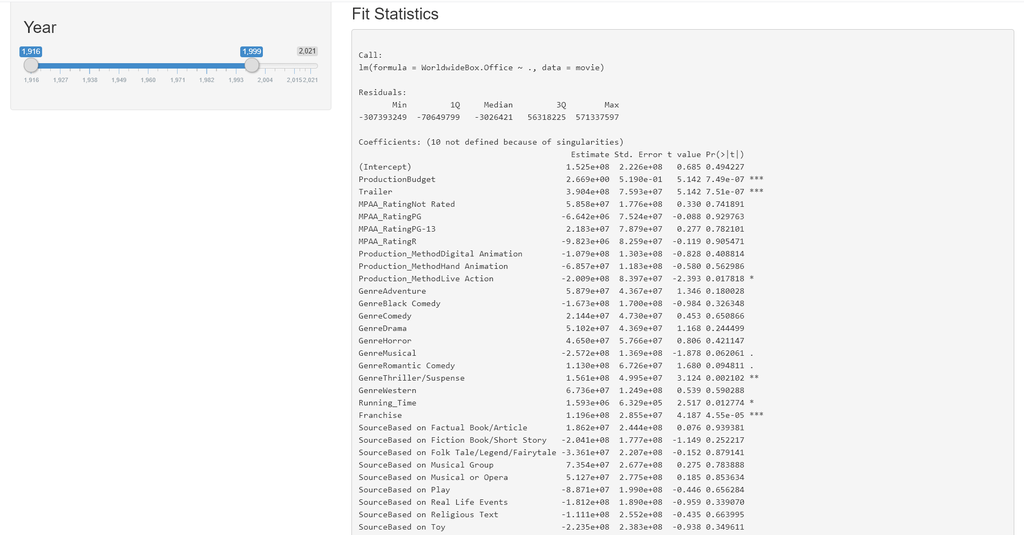

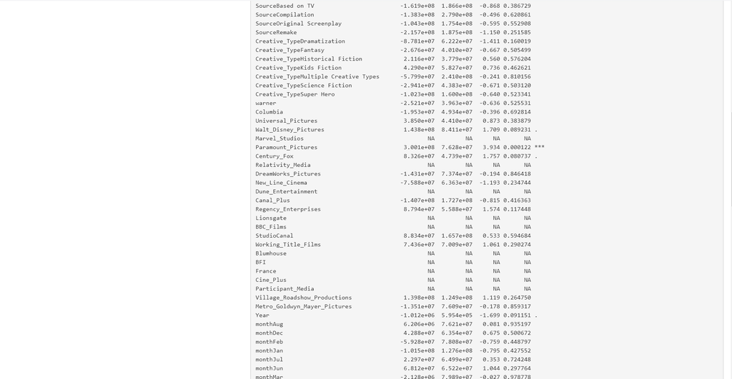

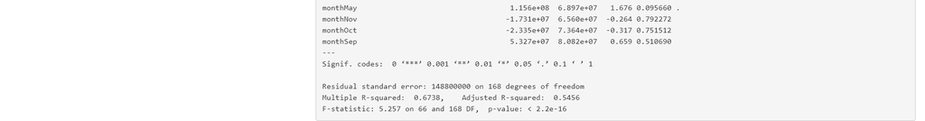

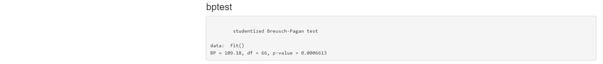

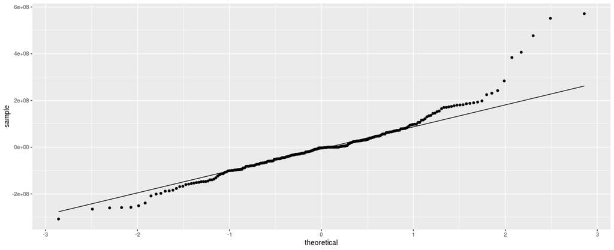

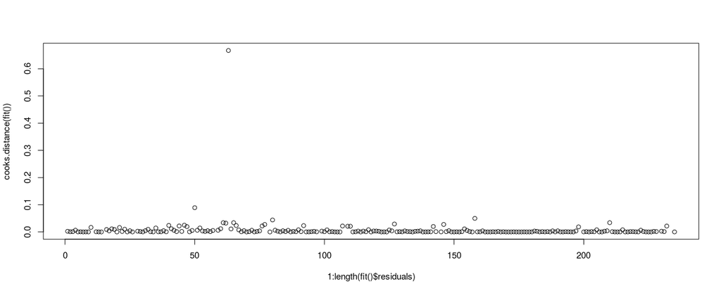

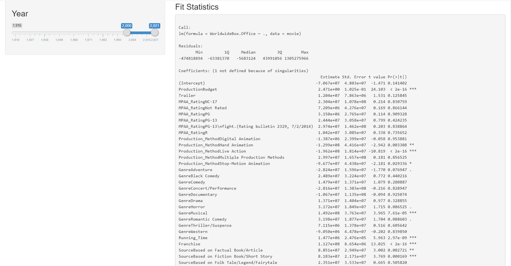

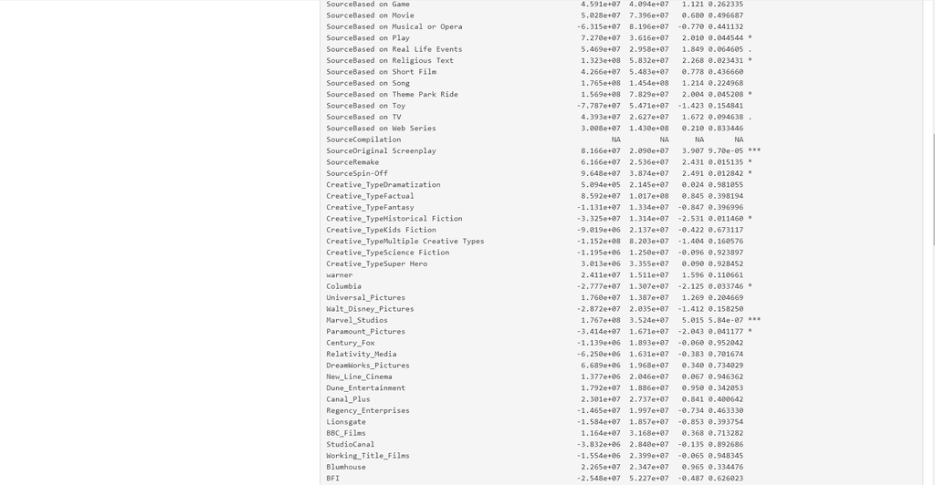

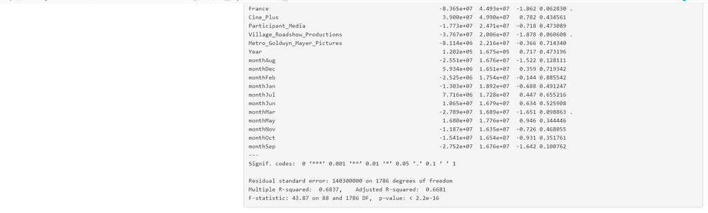

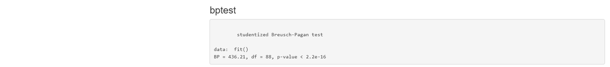

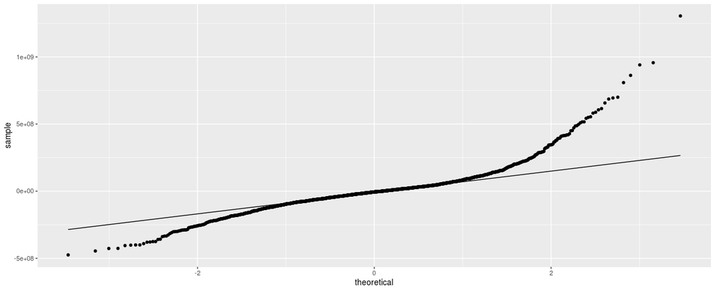

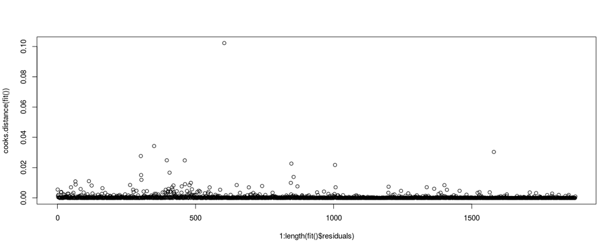